# Most Recent USFWS Klamath Falls National Fish Hatchery Report - 2024

Badhia Yunes Katz (FlowWest)

2025-11-19

The purpose of this markdown is to understand the data available in the most recent Hatchery report, identify questions or data gaps.

**Failure indicators:**

- Acute Pond Mortality: “Unusually cooler water temperatures caused zooplankton crashes and subsequent lethal dissolved oxygen levels in mid-to-late August, leading to the acute loss of several thousand fish. This resulted in fish mortality being much higher in the summer months of FY24 than previously observed, likely due to crowding caused by limited pond space”
- High Intensive Rearing Losses: “Since larval pond space was limited, nearly 5,000–6,000 fry were kept indoors for over two months. This extended intensive rearing period resulted in an overall survival rate of 67.5% for wild-caught larval suckers, with 23.0% recorded as unobserved mortality, likely due to cumulative human error”
- Captive SNS Spawning Failure: “Experimental efforts to spawn captive Shortnose Suckers (SNS) were unsuccessful because pond temperatures increased too quickly (from under 12°C to over 18–19°C), causing milt volume to diminish and eggs to begin being reabsorbed”
- UKL Net Pen Program Suspension: “Production fish were not stocked into the Upper Klamath Lake net pen for grow out due to multiple years of low survival (historical average of 28.2%) at that location”

## Fish distrubution summary

Summary of all fish distributions for repatriation or transfer from the Klamath Falls National Fish Hatchery during the fiscal year of 2024. The distribution efforts are often referred to as “stocking or repatriation events” (distributions), which are considered the “end of the road for the fish”. These can be released to into the wild, or transferred for temporary holding.

| stock_date | species | lot | number | weight_lb | actual_tl_mm | number_lb | projected_tl_inches | projected_tl_mm | from_ponds | stocking_location |
| --- | --- | --- | --- | --- | --- | --- | --- | --- | --- | --- |
| 10/17/2023 | LRS | Mixed | 238 | 98.690 | 270.00 | 2.41 | 10.97 | 279 | A1 | North Refuge Pond |
| 10/17/2023 | SNS | Mixed | 169 | 91.770 | 279.00 | 1.84 | 11.42 | 290 | A1 | North Refuge Pond |
| 10/18/2023 | LRS | 2022 | 208 | 25.820 | 185.00 | 8.06 | 7.34 | 186 | P17 | ODOT Pond |
| 10/18/2023 | SNS | 2022 | 296 | 46.040 | 184.00 | 6.43 | 7.53 | 191 | P17 | ODOT Pond |
| 10/18/2023 | LRS | Mixed | 163 | 65.410 | 269.00 | 2.49 | 10.85 | 276 | A1 | South Refuge Pond |
| 10/18/2023 | SNS | Mixed | 161 | 67.410 | 254.00 | 2.39 | 10.47 | 266 | A1 | South Refuge Pond |
| 10/18/2023 | LRS | 2022 | 918 | 117.660 | 185.00 | 7.80 | 7.42 | 188 | P17, A2 | Sprague River @ Beatty Gap |
| 10/18/2023 | SNS | 2022 | 1039 | 166.920 | 192.00 | 6.22 | 7.61 | 193 | P17, A2 | Sprague River @ Beatty Gap |
| 10/19/2023 | LRS | 2022 | 837 | 107.740 | 186.00 | 7.77 | 7.43 | 189 | A2 | Odessa Springs |
| 10/19/2023 | SNS | 2022 | 1492 | 241.100 | 192.00 | 6.19 | 7.62 | 194 | A2 | Odessa Springs |
| 10/24/2023 | LRS | 2022 | 556 | 85.100 | 195.00 | 6.53 | 7.87 | 200 | P9, P11, P13, P15 | Henzel Boat Ramp |
| 10/24/2023 | SNS | 2022 | 1049 | 213.100 | 209.00 | 4.92 | 8.23 | 209 | P9, P11, P13, P15 | Henzel Boat Ramp |
| 10/26/2023 | LRS | 2022 | 625 | 120.170 | 213.00 | 5.20 | 8.49 | 216 | P10, P12, P14, P16 | Williamson River @ TNC |
| 10/26/2023 | SNS | 2022 | 1046 | 224.520 | 212.00 | 4.66 | 8.38 | 213 | P10, P12, P14, P16 | Williamson River @ TNC |
| 10/27/2023 | LRS | Mixed | 100 | 59.480 | 307.00 | 1.68 | 12.37 | 314 | A1 | Bare Island - Telemetry Fish |
| 10/27/2023 | SNS | Mixed | 237 | 183.580 | 317.00 | 1.29 | 12.85 | 326 | A1 | Bare Island - Telemetry Fish |
| 10/3/2023 | LRS | Salvage | 5 | 27.050 | 631.20 | 0.18 | 25.83 | 656 | LKNWR Salvage (Dams Out) | Williamson River @ TNC |
| 10/3/2023 | SNS | Salvage | 178 | 323.830 | 446.50 | 0.55 | 17.08 | 434 | LKNWR Salvage (Dams Out) | Williamson River @ TNC |
| october total | LRS | Mixed | 501 | 223.580 | NA | 2.24 | 11.24 | 286 | NA | NA |
| october total | SNS | Mixed | 567 | 342.760 | NA | 1.65 | 11.83 | 301 | NA | NA |
| october total | LRS | 2022 | 3144 | 456.490 | NA | 6.89 | 7.73 | 196 | NA | NA |
| october total | SNS | 2022 | 4922 | 891.680 | NA | 5.52 | 7.92 | 201 | NA | NA |
| october total | LRS | Salvage | 5 | 27.050 | NA | 0.18 | 25.83 | 656 | NA | NA |
| october total | SNS | Salvage | 178 | 323.830 | NA | 0.55 | 17.08 | 434 | NA | NA |
| 11/22/2023 | Unknown | Salvage | 5 | 0.190 | NA | 26.32 | 4.95 | 126 | J-Canal Salvage | Malone Springs |
| november total | Unknown | Salvage | 5 | 0.190 | NA | 26.32 | 4.95 | 126 | NA | NA |
| 2/20/2024 | Unknown | Salvage | 452 | 15.230 | 116.15 | 29.68 | 4.75 | 121 | J-Canal Salvage | Malone Springs |
| 2/26/2024 | Unknown | Salvage | 59 | 1.570 | 108.12 | 37.58 | 4.39 | 112 | J-Canal Salvage | Mouth of Four Mile Canal |
| february total | Unknown | Salvage | 511 | 16.800 | NA | 30.42 | 4.71 | 120 | NA | NA |
| 3/12/2024 | LRS | Mixed | 220 | 98.770 | 265.39 | 2.23 | 10.71 | 272 | LKNWR | Williamson River @ Sportsmans |
| 3/12/2024 | SNS | Mixed | 168 | 81.650 | 262.54 | 2.06 | 11.00 | 279 | LKNWR | Williamson River @ Sportsmans |
| 3/18/2024 | Unknown | Salvage | 102 | 2.820 | 113.90 | 36.17 | 4.45 | 113 | J-Canal Salvage | Agency Lake @ Henzel Boat Ramp |
| 3/21/2024 | LRS | 2022 | 688 | 42.780 | 140.74 | 16.08 | 5.54 | 141 | P10, P11 | Lakeside Farms |
| 3/21/2024 | LRS | 2022 | 135 | 7.970 | 136.61 | 16.94 | 5.45 | 138 | P12 | Lower Klamath Lake National Wildlife Refuge |
| 3/21/2024 | SNS | 2022 | 169 | 12.150 | 143.63 | 13.91 | 5.82 | 148 | P12 | Lower Klamath Lake National Wildlife Refuge |
| march total | LRS | Mixed | 220 | 98.770 | NA | 2.23 | 11.27 | 286 | NA | NA |
| march total | SNS | Mixed | 168 | 81.650 | NA | 2.06 | 11.00 | 279 | NA | NA |
| march total | LRS | 2022 | 823 | 50.750 | NA | 27.32 | 4.88 | 124 | NA | NA |
| march total | SNS | 2022 | 169 | 12.150 | NA | 13.91 | 5.82 | 148 | NA | NA |
| march total | Unknown | Salvage | 102 | 2.820 | NA | 36.17 | 4.45 | 113 | NA | NA |
| 6/6/2024 | ESS LRS | 2024 | 4632 | 0.077 | 10.00 | 60155.84 | 0.38 | 10 | Salvage Building Recirc Racks | Transfer - Klamath Tribes Hatchery |
| june total | ESS LRS | 2024 | 4632 | 0.077 | NA | 60155.84 | 0.38 | 10 | NA | NA |
| 9/10/2024 | LRS | 2023 | 17 | 2.600 | 198.00 | 6.54 | 7.87 | 200 | Gerber Net Pens - GERE and GERW | Williamson River @ Sportsmans |
| 9/10/2024 | SNS | 2023 | 1300 | 229.400 | 203.00 | 5.67 | 7.85 | 199 | Gerber Net Pens - GERE and GERW | Williamson River @ Sportsmans |
| 9/17/2024 | LRS | Mixed | 156 | 65.630 | 287.00 | 2.38 | 11.02 | 280 | Refuge Ponds | Transfer - Agency Lake, 4 Mile Canal Net Pen - Telemetry Study |
| 9/17/2024 | SNS | Mixed | 250 | 83.150 | 246.00 | 3.01 | 9.69 | 246 | Refuge Ponds | Transfer - Agency Lake, 4 Mile Canal Net Pen - Telemetry Study |
| 9/27/2024 | LRS | 2022 | 14 | 3.090 | 222.00 | 4.53 | 8.89 | 226 | P21 | Transfer - Agency Lake, 4 Mile Canal Net Pen - Telemetry Study |
| 9/27/2024 | SNS | 2022 | 182 | 44.520 | 220.00 | 4.09 | 8.75 | 222 | P21 | Transfer - Agency Lake, 4 Mile Canal Net Pen - Telemetry Study |
| september total | LRS | 2022 | 14 | 3.090 | NA | 4.53 | 8.89 | 226 | NA | NA |
| september total | SNS | 2022 | 182 | 44.520 | NA | 4.09 | 8.75 | 222 | NA | NA |
| september total | LRS | 2023 | 17 | 2.600 | NA | 6.54 | 7.87 | 200 | NA | NA |
| september total | SNS | 2023 | 1300 | 229.400 | NA | 5.67 | 7.85 | 199 | NA | NA |
| september total | ESS LRS | 2024 | 4632 | 0.077 | NA | 60155.84 | 0.38 | 10 | NA | NA |
| september total | LRS | Mixed | 156 | 65.630 | NA | 2.38 | 11.02 | 280 | NA | NA |
| september total | SNS | Mixed | 250 | 83.150 | NA | 3.01 | 9.69 | 246 | NA | NA |
| fy24 spp. total | LRS | Total | 4875 | 900.910 | NA | 5.41 | 8.38 | 213 | NA | NA |
| fy24 spp. total | SNS | Total | 7558 | 1685.310 | NA | 4.48 | 8.49 | 216 | NA | NA |
| fy24 spp. total | ESS LRS | Total | 4632 | 0.077 | NA | 60155.84 | 0.38 | 10 | NA | NA |
| fy24 spp. total | Unknown | Total | 801 | 370.690 | NA | 26.32 | 4.95 | 126 | NA | NA |
| stocking total | Production | NA | 11831 | 2389.830 | NA | 4.95 | 8.63 | 219 | NA | NA |
| stocking total | Salvage | NA | 801 | 370.690 | NA | 2.16 | 11.38 | 289 | NA | NA |
| transfer total | Fry | NA | 4632 | 0.077 | NA | 60155.84 | 0.38 | 10 | NA | NA |
| transfer total | Production | NA | 602 | 196.390 | NA | 3.07 | 10.13 | 257 | NA | NA |
| overall | Production | NA | 12433 | 2586.220 | NA | 4.81 | 8.72 | 221 | NA | NA |
| distribution | Fry | NA | 4632 | 0.077 | NA | 60155.84 | 0.38 | 10 | NA | NA |
| total | Salvage | NA | 801 | 370.690 | NA | 2.16 | 11.38 | 289 | NA | NA |
| total | Overall | NA | 17866 | 2956.990 | NA | 6.04 | 8.08 | 205 | NA | NA |

## KFNFH Historical Collections and Releases Summary (2016–FY24)

- Larvae collected: The total number of wild larval suckers collected, primarily from the lower Williamson River, for production purposes
- SARP release: The number of “Production Fish” released. These are fish raised to the target size of approximately 200 mm total length (TL), typically taking 18–24 months
- Fingerling release: The number of smaller, excess fish stocks (beyond rearing capacity) that were transferred or released into off-channel rearing locations
- Fry release: The number of small fish released, generally produced from experimental or wild-spawning activities on the lake and river side, or transferred to other facilities
- Salvage release: The number of suckers salvaged during the year (e.g., from Klamath Project Operations or dam removal efforts) that were rehabilitated, tagged, and then repatriated (released back to the wild)
- TL vs SL: The average Standard Length (SL) or Total Length (TL) are both in millimeters for the salvaged fish, however, they are inconsistently collected- SL in earlier years (2018–2021) and TL in later years (2023–2024)

| fiscal_year | larvae_collected | sarp_release | sarp_tl_mm | fingerling_release | fingerling_tl_mm | fry_release | fry_tl_mm | salvage_release | salvage_sl_mm | salvage_tl_mm |
| --- | --- | --- | --- | --- | --- | --- | --- | --- | --- | --- |
| 2016 | 4134 | NA | NA | NA | NA | NA | NA | NA | NA | NA |
| 2017 | 8730 | NA | NA | NA | NA | NA | NA | NA | NA | NA |
| 2018 | 9544 | 2355 | 147 | NA | NA | NA | NA | 784 | 102 | NA |
| 2019 | 24426 | 4497 | 189 | NA | NA | NA | NA | 1586 | 103 | NA |
| 2020 | 40603 | 11774 | 223 | NA | NA | NA | NA | 1928 | 94 | NA |
| 2021 | 106710 | 13394 | 208 | NA | NA | NA | NA | 1689 | 143 | NA |
| 2022 | 51929 | 12768 | 193 | 4655 | 118 | 19993 | 10 | NA | NA | NA |
| 2023 | 6036 | 17399 | 194 | 15604 | 89 | 14973 | 10 | 436 | NA | 129 |
| 2024 | 30150 | 12433 | 221 | NA | NA | 4632 | 10 | 801 | NA | 126 |

## Wild Adult LRS Handled

Inventory of the individual wild adult Lost River Suckers (LRS) handled by KFNFH staff during the spawning collection efforts at the East Side Springs (ESS) of Upper Klamath Lake in 2024. The table summarizes the wild LRS captured, identifying their physical characteristics, tagging information, and how their gametes were used.

- Lists the four dates when gamete collection occurred: April 17, April 24, May 1, and May 8, 2024.
- documents the total of 43 wild adult LRS handled (13 females and 30 males). All these fish were returned safely to the water thereafter.
- confirms the sex of the fish and whether they were “Spawned” or “Not Spawned”. Twenty-four of the 30 males were spawned.
- gamete_use column notes they were “Cryo Preservation” or “Spawned/Cryopreservation,” indicating that excess milt was used for cryopreservation trials.
- family_groups: most females were crossed with four males, though one female was crossed with two, totaling 50 family groups collected overall. This column applies only to the females.

**Success indicators:** - Incubation Improvement: KFNFH staff achieved a significant milestone by increasing onsite hatching rates from around 20% to over 70%. This table shows information on the male and female Lost River Suckers used in the spawning effort and the incubation results for each female - Successful captive LRS spawning: hatchery pawned and hatched an estimated 56,458 larval Lost River Suckers on station from gametes collected from the East Side Springs population. (this number is at the very bottom of the table but was not read in here. It is the sum of all rows under total_fry) - Monitoring Success: A pilot effort deploying PIT tag monitoring arrays detected 416 unique PIT tagged fish, with 246 (59.1%) having originated from the hatchery (as reared fish or rehabilitated salvage fish)

**Failure indicators:**

```
#> Rows: 43
#> Columns: 8
#> $ date                         <date> 2024-04-17, 2024-04-17, 2024-04-17, 2024…
#> $ fin_clip_id_number           <chr> "3960-049", "3960-050", "3960-051", "3960…
#> $ pit_tag_suffix               <chr> "257C5DBC9C", "003D6D4420", "003D485428",…
#> $ sex                          <chr> "Male", "Male", "Male", "Male", "Female",…
#> $ gamete_use                   <chr> "Spawned", "Spawned", "Spawned", "Spawned…
#> $ fork_length                  <dbl> 690, 543, 538, 615, 787, 743, 727, 730, 7…
#> $ total_length_spring_location <chr> "732 CINDER", "584 SUCKER", "572 SUCKER",…
#> $ family_groups                <dbl> NA, NA, NA, NA, 4, 4, 4, 4, 4, 4, 4, NA, …
```

## Summary of Incubation and Hatch Results

Quantitative results of the fertilization and incubation trials conducted using the gametes collected from the wild LRS documented in wild_lrs_adults table.

**Success indicators:** - Incubation Improvement: KFNFH staff achieved a significant milestone by increasing onsite hatching rates from around 20% to over 70%

**Failure indicators:**

```
#> Rows: 14
#> Columns: 12
#> $ spawning_date   <date> 2024-04-17, 2024-04-17, 2024-04-24, 2024-04-24, 2024-…
#> $ female          <chr> "003D6B96AC", "003D6B96AC", "257C5DC4F7", "003D6D42B0"…
#> $ male_1          <chr> "257C5DBC9C", "257C5DBC9C", "003D6D42A2", "003D6B9717"…
#> $ male_2          <chr> "003D6D4420", "003D6D4420", "003C08DB3F", "003BC11270"…
#> $ male_3          <chr> "003D485428 003BBFCD43", "003D485428 003BBFCD43", "003…
#> $ incubator       <chr> "aquaria", "jars", "jars", "jars", "jars", "jars", "ja…
#> $ egg_volume_m_l  <dbl> 28.16, 192.00, 170.00, 175.00, 295.00, 200.00, 125.00,…
#> $ number_eggs_m_l <dbl> 42.60, 42.60, 34.33, 47.00, 35.00, 35.00, 30.33, 34.00…
#> $ total_eggs      <dbl> 1200, 8179, 5836, 8225, 10325, 7000, 3791, 5440, 2730,…
#> $ total_fry       <dbl> 483, 5258, 4086, 2253, 11090, 3346, 517, 547, 2799, 64…
#> $ hatch_percent   <dbl> 40.3, 64.3, 70.0, 27.4, 107.4, 47.8, 13.6, 10.1, 102.5…
#> $ hatch_date      <date> 2024-04-24, 2024-04-22, 2024-05-02, 2024-05-02, 2024-…
```

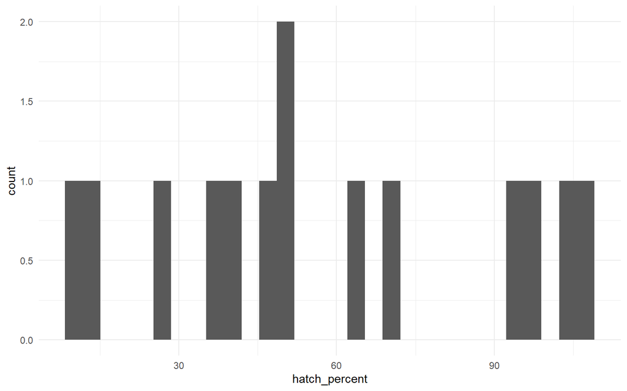

Mean Hatch (%) grouped by the four Spawning Dates (April 17, 24, May 1, May 8)

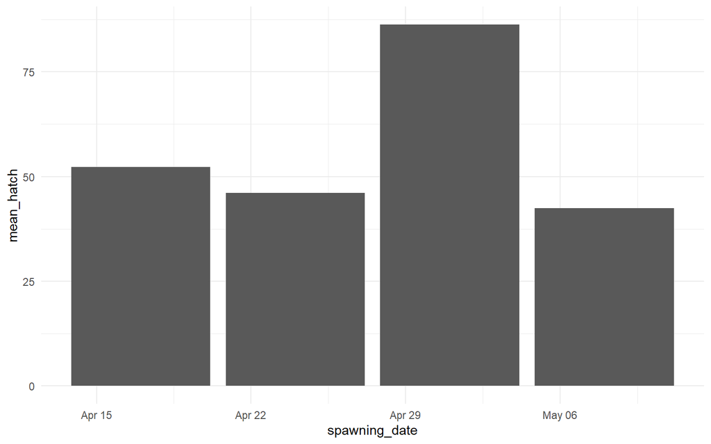

Egg Volume vs. Fry Production (Scatter Plot)

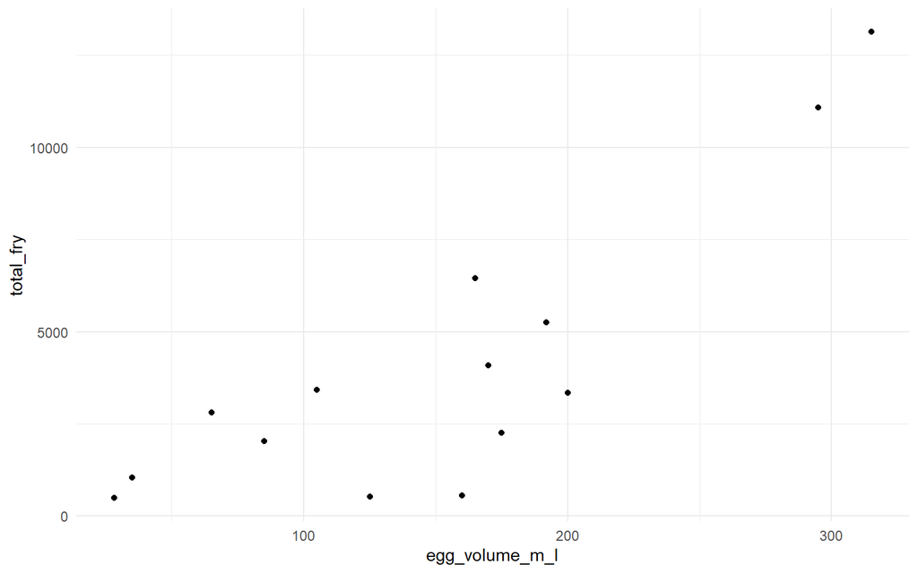

Total Eggs ovs Total Fry hatched

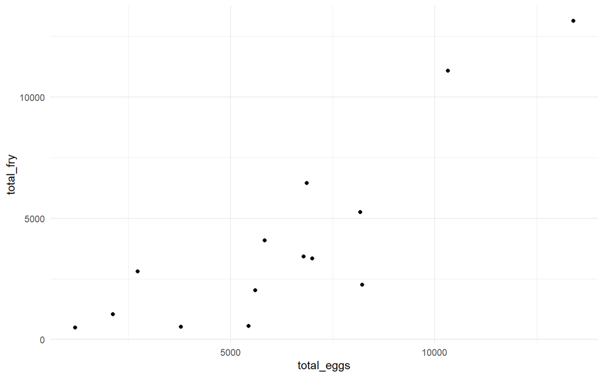

## Historical Larval Sucker Collection Summary (2016–2024)

Historical timeline of the wild larval suckers collected from the lower Williamson River near Chiloquin, Oregon, used for production purposes at the Klamath Falls National Fish Hatchery (KFNFH)

**Success indicators:** - collection of 30,150 Klamath sucker fry. This was much higher than the previous year’s and provided enough larvae to meet the year’s production goals despite the lack of space

**Failure indicators:**

[figure not shown]

```
#> Rows: 9
#> Columns: 3
#> $ year_spring               <dbl> 2016, 2017, 2018, 2019, 2020, 2021, 2022, 20…
#> $ number_collected          <dbl> 4134, 8730, 9544, 24426, 40603, 106710, 5192…
#> $ primary_collection_method <chr> "Drift Net (Passive Method)", "Drift Net (Pa…
```

Annual Larval Collection Trend

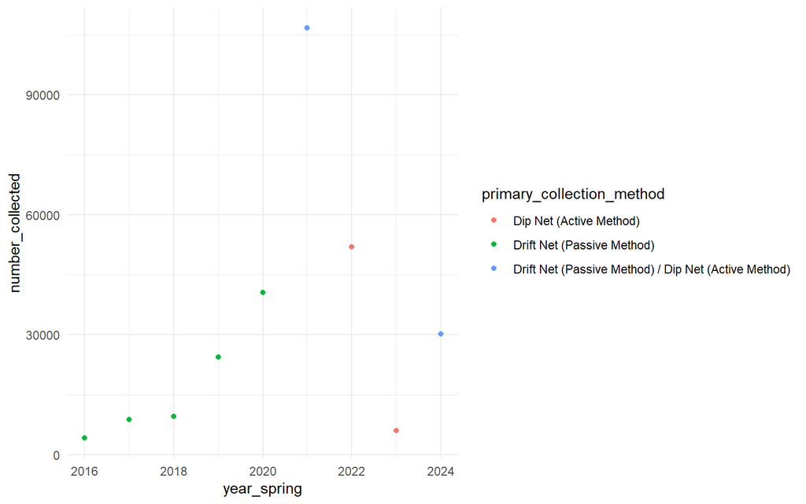

## Larval Early Rearing Mortality and Survival by Tank (FY24)

- culture_unit: specific tank the fish were placed in (e.g., C3, C4). rows marked “Restock” indicate instances where a culture unit was used for a second or subsequent batch of collected fish
- collected: initial number of fish placed in the unit (Total: 30,150)
- stocked: final number of fish transferred or stocked out of the tank
- unobserved_mortality_percent: calculated based on the difference between collected fish and the sum of observed mortality and stocked fish

```
#> Rows: 25
#> Columns: 8
#> $ date                         <date> 2024-05-08, 2024-05-10, 2024-05-13, 2024…
#> $ culture_unit                 <chr> "C3 (Salvage Building)", "C4 (Salvage Bui…
#> $ collected                    <dbl> 18, 56, 78, 322, 1328, 1078, 5165, 2133, …
#> $ mortality                    <dbl> 0, 0, 0, 4, 15, 77, 448, 20, 100, 707, 6,…
#> $ stocked                      <dbl> 18, 55, 58, 83, 1211, 765, 2566, 1973, 12…
#> $ survival_percent             <dbl> 100.0, 98.2, 74.4, 25.8, 91.2, 71.0, 49.7…
#> $ observed_mortality_percent   <dbl> 0.0, 0.0, 0.0, 1.2, 1.1, 7.1, 8.7, 0.9, 6…
#> $ unobserved_mortality_percent <dbl> 0.0, 1.8, 25.6, 73.0, 7.7, 21.9, 41.6, 6.…
```

Mortality and Loss Breakdown by Culture Unit

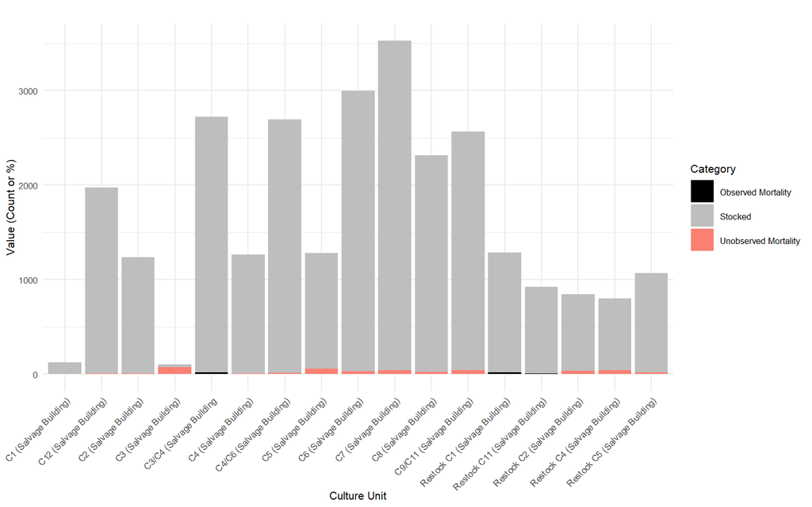

Observed Mortality, Unobserved Mortality, and Survival Over Date

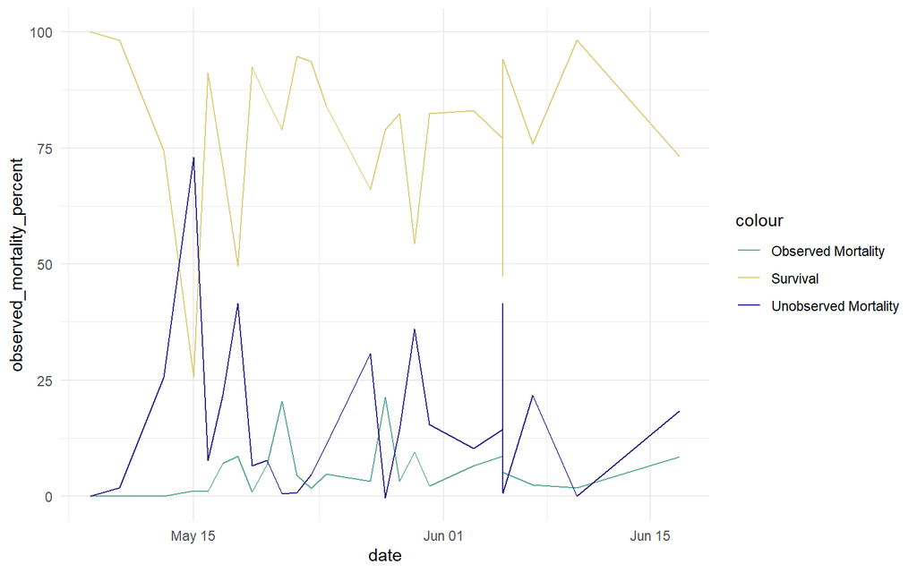

## Pond Monitoring - Spring 2023 – Fall 2023 - Main Growout Season (pre-FY24)

Pond, collection year, stocking date, number of suckers on stocking date, average weight per fish, total weight of all fish in each pond (used to derive feeding amounts), average total length on stocking date (mm, measured or derived from length weight relationships, date harvested, number of suckers on harvest date, growth, and survival for ponds during the production cycle starting in the Spring of 2023 through the Fall of 2023 at the Klamath Falls National Fish Hatchery.

- P-series vs A-series ponds: two sets of outdoor rearing spaces distinguished primarly by size and operational status
- P-Series pond: Small ponds, typically 0.03-acre each,
  - Primary growout space.
  - Twenty-two P-series ponds remained operational throughout most of FY24
- A-series ponds: Larger ponds, typically 0.25-acre each
  - Demolished early in FY24
- “start_weight_fish” (Average Weight Per Fish in Grams): This column records the average weight of a single sucker within a given pond lot at the time the fish were initially stocked into that pond
- “start_wt_g” (Total Weight of All Fish in Grams): This column records the cumulative total weight (biomass) of all the suckers in that specific pond lot at the time they were stocked (“Start Date”). This total weight is the critical metric used by staff to derive daily feeding amounts for the fish in that pond

```
#> Rows: 25
#> Columns: 32
#> $ pond                     <chr> "P1", "P2", "P3", "P4", "P5", "P6", "P7", "P8…
#> $ lot                      <chr> "2018", "2018", "2019", "2019", "2020", "2021…
#> $ stocked_date             <date> 2023-03-14, 2023-03-14, 2023-03-14, 2023-03-…
#> $ start_number             <dbl> 103, 100, 102, 100, 302, 311, 3631, 84, 501, …
#> $ g_fish                   <chr> "309.20", "294.20", "303.70", "303.70", "125.…
#> $ g                        <chr> "31847.6", "29420", "30977.4", "30370", "3781…
#> $ lb                       <chr> "70.15", "64.80", "68.23", "66.89", "83.28", …
#> $ mm                       <chr> "307", "307", "220", "299", "222", "183", "0.…
#> $ harvest_date             <date> 2023-11-29, 2023-11-29, 2023-11-28, 2023-11-…
#> $ end_number               <dbl> 89, 86, 91, 91, 263, 266, 2078, 85, 467, 498,…
#> $ g_fish_2                 <chr> "461.76", "426.07", "426.51", "458.22", "233.…
#> $ g_2                      <chr> "41097", "36642", "38812", "41698", "61451", …
#> $ lb_2                     <chr> "90.52", "80.71", "85.49", "91.85", "135.35",…
```

[output cut: 19 more lines]

Growth rate vs start total length in mm

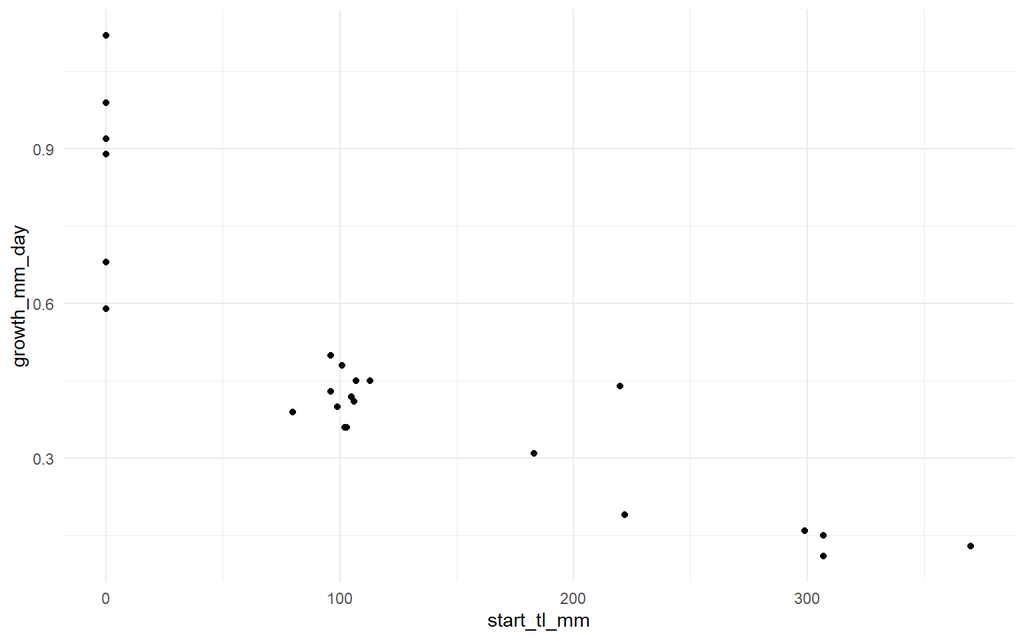

Start and end weight per pond

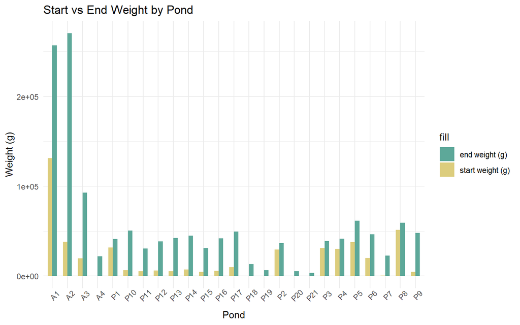

Days in the pond vs growth per day (mm)

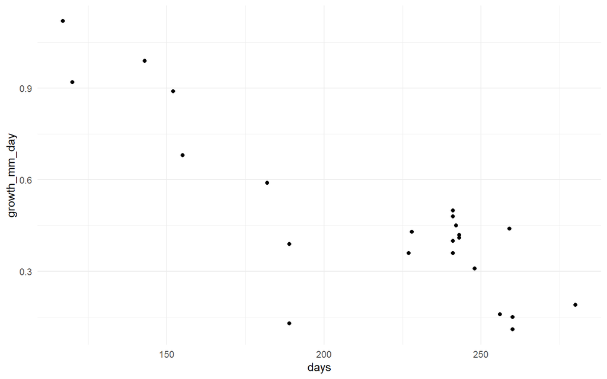

- question: would this be fall of 2023 only?
- there are a lot of missing values on this table

```
#> Rows: 16
#> Columns: 20
#> $ pond                     <chr> "P0", "P1", "P2", "P3", "P4", "P5", "P6", "P7…
#> $ lot                      <chr> "2023", "2018", "2018", "2019", "2019", "2020…
#> $ stocked_date             <date> 2023-10-26, 2023-12-01, 2023-12-04, 2023-12-…
#> $ start_number             <dbl> 818, 86, 86, 91, 91, 262, 266, 85, 401, 1052,…
#> $ start_g_fish             <dbl> 24.51, 477.87, 426.07, 426.51, 458.22, 234.55…
#> $ start_wt_g               <dbl> 20048, 41097, 36642, 38812, 41698, 61451, 465…
#> $ start_wt_lb              <dbl> 44.16, 90.52, 80.71, 85.49, 91.85, 135.35, 10…
#> $ start_tl_mm              <dbl> 141, 345, 336, 335, 341, 275, 261, 395, 217, …
#> $ harvest_date             <date> 2024-02-27, NA, NA, NA, NA, 2024-05-15, NA, …
#> $ end_number               <dbl> 805, 86, 86, 91, 91, 259, 266, 85, 401, 1047,…
#> $ end_g_fish               <dbl> 17.8997, NA, NA, NA, NA, 237.0100, NA, 673.55…
#> $ end_wt_g                 <dbl> 14105.00, NA, NA, NA, NA, 61385.59, NA, 57251…
#> $ end_gt_lb                <dbl> 31.0700, NA, NA, NA, NA, 135.2106, NA, 126.10…
#> $ end_tl_mm                <dbl> NA, NA, NA, NA, NA, 306, NA, 426, NA, 145, 14…
#> $ days                     <dbl> 124, NA, NA, NA, NA, 167, NA, 171, NA, 139, 1…
#> $ months                   <dbl> 10.33000, NA, NA, NA, NA, 5.56667, NA, 5.7000…
#> $ growth_mm_day            <dbl> NA, NA, NA, NA, NA, 0.1856287, NA, 0.1812865,…
#> $ weight_gain_lb           <dbl> -13.0900000, NA, NA, NA, NA, -0.1440749, NA, …
#> $ harvest_mortality_number <dbl> 17, NA, NA, NA, NA, 0, NA, 0, NA, 9, 3, 14, 1…
#> $ survival_percent         <dbl> 98.4, NA, NA, NA, NA, 98.9, NA, 100.0, NA, 99…
```

Growth rate vs start total length in mm

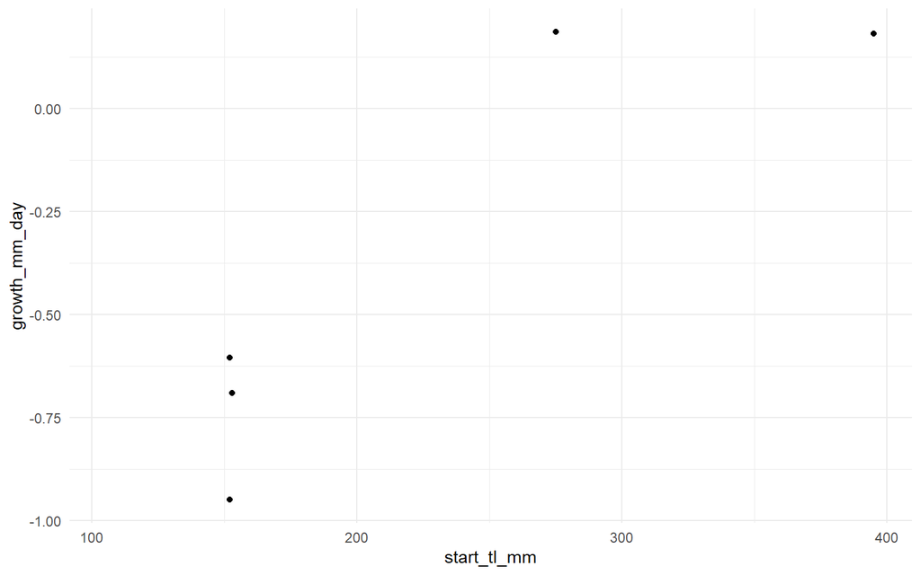

Start and end weight per stocked date/pond

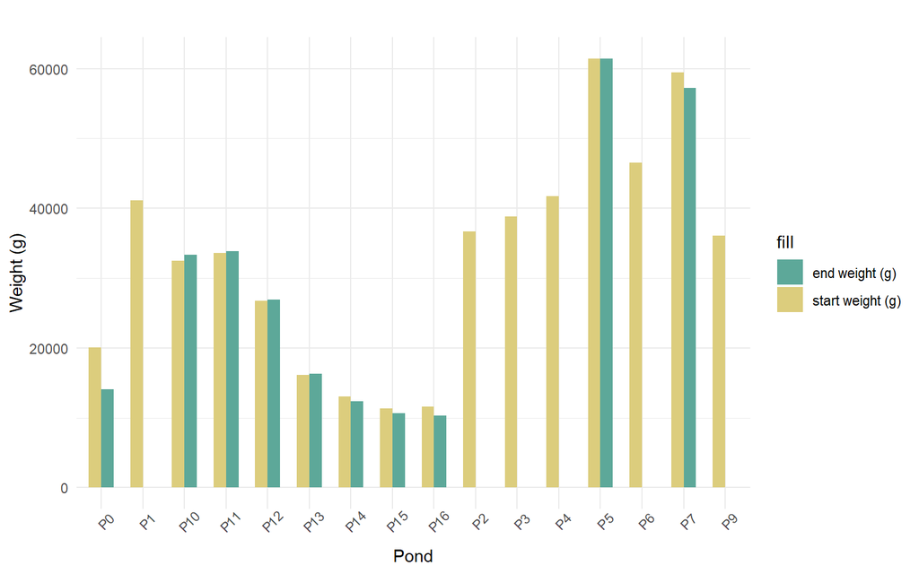

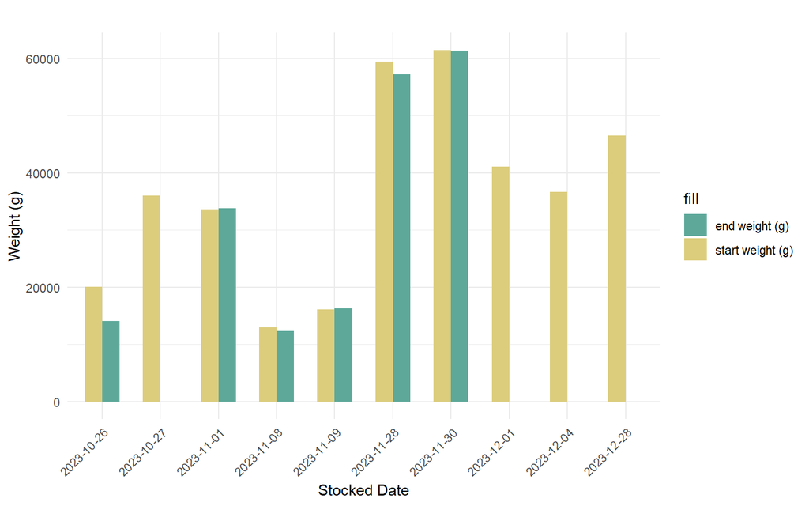

Days in the pond vs growth per day (mm)

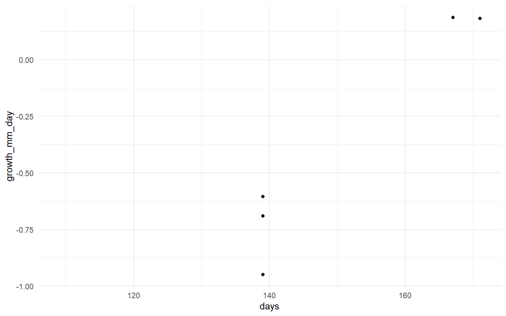

## Pond Monitoring - Fall 2023 or Spring 2024 through Fall 2024

Subsequent growing season 2024 (Fall 2023/Spring 2024 through Fall 2024. Production cycle starting in the Fall of 2023 or Spring of 2024 through the Fall of 2024 at the Klamath Falls National Fish Hatchery. Please note that Fall inventory work was not completed for most ponds prior to the close of FY 2024.

```
#> Rows: 26
#> Columns: 20
#> $ x1_pond                  <chr> "P0", "P1", "P2", "P3", "P4", "P5", "P6", "P7…
#> $ x2_lot                   <chr> "2020", "2018", "2018", "2019", "2019", "2020…
#> $ x3_stocked_date          <chr> "5/15/2024", "12/1/2023", "12/4/2023", "12/1/…
#> $ x4_start_number          <chr> "127", "86", "86", "91", "91", "132", "266", …
#> $ start_g_fish             <chr> "237.01", "477.87", "426.07", "426.51", "458.…
#> $ start_wt_g               <chr> "30100", "41097", "36642", "38812", "41698", …
#> $ start_wt_2_lb            <chr> "66.3", "90.52", "80.71", "85.49", "91.85", "…
#> $ start_tl_mm              <chr> "306", "345", "336", "335", "341", "306", "26…
#> $ x9_harvest_date          <chr> NA, NA, NA, NA, NA, NA, NA, NA, NA, NA, NA, N…
#> $ x10_end_number           <chr> NA, NA, NA, NA, NA, NA, NA, NA, NA, NA, NA, N…
#> $ end_g_fish               <chr> NA, NA, NA, NA, NA, NA, NA, NA, NA, NA, NA, N…
#> $ end_wt_12_g              <chr> NA, NA, NA, NA, NA, NA, NA, NA, NA, NA, NA, N…
#> $ end_wt_13_lb             <chr> NA, NA, NA, NA, NA, NA, NA, NA, NA, NA, NA, N…
```

[output cut: 29 more lines]

## UKL Sucker Pen survival

- Each operation year is divided by the different fish pens (UKLN, UKLS, UKLW, UKLE) and the year the fish were captured as larval fish from the Williamson River (CY).
- CY: captured year
- The average total length (TL) in millimeters (mm): to show survival of each operation year.
- Operation year 2020 is an outlier year as fish were not stocked until fall and only held for two months
- no production fish were stocked in 2024 as the future of using the UKL net pen to grow suckers is being assessed by USFWS.

```
#> Rows: 11
#> Columns: 8
#> $ operation_year      <dbl> 2019, 2019, 2020, 2021, 2021, 2021, 2021, 2022, 20…
#> $ captured_year       <dbl> 2018, 2017, 2019, 2019, 2020, 2019, 2020, 2021, 20…
#> $ pen_id              <chr> "UKLN", "UKLS", "UKLN", "UKLN", "UKLN", "UKLS", "U…
#> $ stock_tl_mm         <dbl> 160, 236, 224, 228, 134, 233, 150, 96, 105, 170, 1…
#> $ number_stocked      <dbl> 534, 480, 220, 100, 900, 150, 1350, 1999, 1852, 10…
#> $ harvest_tl_mm       <dbl> 0, 263, 233, 0, 0, 280, 210, 142, 155, 221, 220
#> $ number_harvested    <dbl> 0, 10, 180, 0, 0, 87, 519, 947, 897, 29, 31
#> $ survival_percentage <dbl> 0.0, 2.1, 81.8, 0.0, 0.0, 58.0, 38.4, 47.4, 48.4, …
```

Survival Percentage by Pen and Year

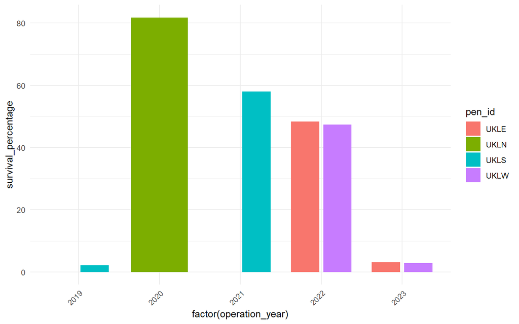

## Gerber net pen sucker survival and growth data

Gerber net pen sucker survival and growth data since the first use of the Gerber net pen in 2021, each operation year is divided by the different fish pens and by the Fish CY (Capture year from the Williamson River as larval fish). The average total length (TL) is in millimeters (mm) of fish stocked in and harvested out of the pen the same year, also shown is number of fish stocked and harvested in the same year for survival of that grow out year. In 2021 fish were pulled out of the net pen early (July) due to low lake levels, and GERE in 2023 show low survival however suckers likely escaped out of multiple holes that were found in net.

| operation_year | captured_year | pen_id | stock_tl_mm | number_stocked | harvest_tl_mm | number_harvested | survival_percentage |
| --- | --- | --- | --- | --- | --- | --- | --- |
| 2021 | 2019 | GERE | 235 | 100 | 269 | 97 | 97.0 |
| 2021 | 2020 | GERE | 140 | 898 | 174 | 827 | 92.1 |
| 2021 | 2019 | GERW | 230 | 150 | 265 | 146 | 97.3 |
| 2021 | 2020 | GERW | 138 | 1331 | 173 | 1105 | 83.0 |
| 2022 | NA | NA | NA | NA | NA | NA | NA |
| 2023 | 2021 | GERE | 170 | 1005 | 225 | 454 | 45.2 |
| 2023 | 2021 | GERW | 171 | 1036 | 214 | 1000 | 96.5 |
| 2024 | 2022 | GERE | 149 | 648 | 205 | 624 | 96.3 |
| 2024 | 2022 | GERW | 148 | 730 | 201 | 693 | 94.9 |